# IMDB dataset - Actor network analysis (Part 1)

What is the key of a successful movie? An interesting story? Beautiful cinematography? A great director? The right cast?

While a cast of top Hollywood stars is a well-known formula for blockbusters, does it also affect the way it's perceived among the audience? Are there actors that bound to act in highly-perceived movies, and actors that bound to act in worse ones? Those questions can partly be answered by an actor network analysis of [this IMDB dataset](https://www.kaggle.com/deepmatrix/imdb-5000-movie-dataset).

We would use [Gephi](https://gephi.org/), an amazing open-source package specialized for network analysis and data visualization. But first of all, we can explore and clean the data with Jupyter notebook.

First, we need to import the necessary library for our analysis. Since we would do most of the analysis with Gephi, we only need to use `pandas`, `numpy` and `matplotlib` in python.

```python
# Import the libraries
import pandas as pd
import numpy as np
import matplotlib.pyplot as plt
```

Then we would use `pandas` to read the csv file:

```python
# Read the csv file
movies = pd.read_csv("movie_metadata.csv")
```

What do we have on hand? Let's find out.

```python
# Print the column names
movies.columns
```

```
Index(['color', 'director_name', 'num_critic_for_reviews', 'duration',
       'director_facebook_likes', 'actor_3_facebook_likes', 'actor_2_name',
       'actor_1_facebook_likes', 'gross', 'genres', 'actor_1_name',
       'movie_title', 'num_voted_users', 'cast_total_facebook_likes',
       'actor_3_name', 'facenumber_in_poster', 'plot_keywords',
       'movie_imdb_link', 'num_user_for_reviews', 'language', 'country',
       'content_rating', 'budget', 'title_year', 'actor_2_facebook_likes',
       'imdb_score', 'aspect_ratio', 'movie_facebook_likes'],
      dtype='object')
```

```python
# How many movies do we have?
movies.shape
```

```
(5043, 28)
```

```python
# Drop the duplicates, just in case.
movies = movies.drop_duplicates()
movies.shape
```

```
(4998, 28)
```

Before concerning about the IMDB scores, we all know the difference between a movie rated by 10 users and a movie rated by 100,000 users. For our analysis, we hopefully would want the movies that are either well-liked or well-disliked universally in the IMDB community. Since IMDB is a big community, how many votes is a movie typically received?

```python
# Summary statistics of num_voted_users
movies['num_voted_users'].describe()
```

```
count    4.998000e+03
mean     8.347020e+04
std      1.380866e+05
min      5.000000e+00
25%      8.560000e+03
50%      3.426050e+04
75%      9.612075e+04
max      1.689764e+06
Name: num_voted_users, dtype: float64
```

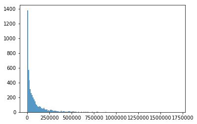

```python
plt.hist(movies['num_voted_users'], 'auto', alpha=0.75)
plt.show()
```

We can see there's a big difference between the minimum number of votes and the maximum one, so we can use the median number of votes to offset both the extremes. For the accuracy of our analysis, we only need movies that are rated by 34,000 users or more:

```python
voted_movies = movies[movies['num_voted_users'] >= 34000]
```

```python
# Summary statistics of the score:
voted_movies['imdb_score'].describe()
```

```
count    2508.000000
mean        6.791707
std         0.954996
min         1.600000
25%         6.200000
50%         6.800000
75%         7.500000
max         9.300000
Name: imdb_score, dtype: float64
```

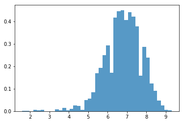

```python
plt.hist(voted_movies['imdb_score'], 'auto', normed = 100, alpha=0.75)
plt.show()
```

```python
voted_movies['imdb_score'].quantile([.90])
```

```
0.9    8.0
Name: imdb_score, dtype: float64
```

```python
voted_movies['imdb_score'].quantile([.25])
```

```
0.25    6.2
Name: imdb_score, dtype: float64
```

We can see that a 8.0 score is at the 90th percentile (very well-liked), while a 6.2 score is at 25th percentile (generally well-disliked). We can subset them as the `high_score` and `low_score` datasets for our analysis.

```python
high_score = voted_movies[(voted_movies['imdb_score'] >= 8.0)]
low_score = voted_movies[(voted_movies['imdb_score'] <= 6.2)]
```

```python
# Sort the dataset by score:
high_score = high_score.sort_values(by = "imdb_score", ascending = False)
```

```python
high_score
```

|  | color | director_name | num_critic_for_reviews | duration | director_facebook_likes | actor_3_facebook_likes | actor_2_name | actor_1_facebook_likes | gross | genres | ... | num_user_for_reviews | language | country | content_rating | budget | title_year | actor_2_facebook_likes | imdb_score | aspect_ratio | movie_facebook_likes |
| --- | --- | --- | --- | --- | --- | --- | --- | --- | --- | --- | --- | --- | --- | --- | --- | --- | --- | --- | --- | --- | --- |
| 1937 | Color | Frank Darabont | 199.0 | 142.0 | 0.0 | 461.0 | Jeffrey DeMunn | 11000.0 | 28341469.0 | Crime\|Drama | ... | 4144.0 | English | USA | R | 25000000.0 | 1994.0 | 745.0 | 9.3 | 1.85 | 108000 |
| 3466 | Color | Francis Ford Coppola | 208.0 | 175.0 | 0.0 | 3000.0 | Marlon Brando | 14000.0 | 134821952.0 | Crime\|Drama | ... | 2238.0 | English | USA | R | 6000000.0 | 1972.0 | 10000.0 | 9.2 | 1.85 | 43000 |
| 66 | Color | Christopher Nolan | 645.0 | 152.0 | 22000.0 | 11000.0 | Heath Ledger | 23000.0 | 533316061.0 | Action\|Crime\|Drama\|Thriller | ... | 4667.0 | English | USA | PG-13 | 185000000.0 | 2008.0 | 13000.0 | 9.0 | 2.35 | 37000 |
| 2837 | Color | Francis Ford Coppola | 149.0 | 220.0 | 0.0 | 3000.0 | Al Pacino | 22000.0 | 57300000.0 | Crime\|Drama | ... | 650.0 | English | USA | R | 13000000.0 | 1974.0 | 14000.0 | 9.0 | 1.85 | 14000 |
| 3481 | Color | NaN | 54.0 | 53.0 | NaN | 1000.0 | Adam Goldberg | 4000.0 | NaN | Crime\|Drama\|Thriller | ... | 173.0 | English | USA | TV-MA | NaN | NaN | 1000.0 | 9.0 | 1.78 | 61000 |
| 4498 | Color | Sergio Leone | 181.0 | 142.0 | 0.0 | 24.0 | Luigi Pistilli | 16000.0 | 6100000.0 | Western | ... | 780.0 | Italian | Italy | Approved | 1200000.0 | 1966.0 | 34.0 | 8.9 | 2.35 | 20000 |
| 1874 | Black and White | Steven Spielberg | 174.0 | 185.0 | 14000.0 | 212.0 | Embeth Davidtz | 14000.0 | 96067179.0 | Biography\|Drama\|History | ... | 1273.0 | English | USA | R | 22000000.0 | 1993.0 | 795.0 | 8.9 | 1.85 | 41000 |
| 3355 | Color | Quentin Tarantino | 215.0 | 178.0 | 16000.0 | 857.0 | Eric Stoltz | 13000.0 | 107930000.0 | Crime\|Drama | ... | 2195.0 | English | USA | R | 8000000.0 | 1994.0 | 902.0 | 8.9 | 2.35 | 45000 |
| 4822 | Black and White | Sidney Lumet | 177.0 | 96.0 | 0.0 | 253.0 | Lee J. Cobb | 359.0 | NaN | Crime\|Drama | ... | 888.0 | English | USA | Not Rated | 350000.0 | 1957.0 | 259.0 | 8.9 | 1.66 | 40000 |
| 339 | Color | Peter Jackson | 328.0 | 192.0 | 0.0 | 416.0 | Billy Boyd | 5000.0 | 377019252.0 | Action\|Adventure\|Drama\|Fantasy | ... | 3189.0 | English | USA | PG-13 | 94000000.0 | 2003.0 | 857.0 | 8.9 | 2.35 | 16000 |
| 836 | Black and White | Robert Zemeckis | 149.0 | 142.0 | 0.0 | 194.0 | Siobhan Fallon Hogan | 15000.0 | 329691196.0 | Comedy\|Drama | ... | 1398.0 | English | USA | PG-13 | 55000000.0 | 1994.0 | 294.0 | 8.8 | 2.35 | 59000 |
| 270 | Color | Peter Jackson | 297.0 | 171.0 | 0.0 | 857.0 | Orlando Bloom | 16000.0 | 313837577.0 | Action\|Adventure\|Drama\|Fantasy | ... | 5060.0 | English | New Zealand | PG-13 | 93000000.0 | 2001.0 | 5000.0 | 8.8 | 2.35 | 21000 |
| 683 | Color | David Fincher | 315.0 | 151.0 | 21000.0 | 637.0 | Meat Loaf | 11000.0 | 37023395.0 | Drama | ... | 2968.0 | English | USA | R | 63000000.0 | 1999.0 | 783.0 | 8.8 | 2.35 | 48000 |
| 1842 | Color | NaN | 79.0 | 22.0 | NaN | 424.0 | Kaitlin Olson | 813.0 | NaN | Comedy | ... | 151.0 | English | USA | TV-MA | NaN | NaN | 547.0 | 8.8 | 1.33 | 0 |
| 2051 | Color | Irvin Kershner | 223.0 | 127.0 | 883.0 | 441.0 | Kenny Baker | 11000.0 | 290158751.0 | Action\|Adventure\|Fantasy\|Sci-Fi | ... | 900.0 | English | USA | PG | 18000000.0 | 1980.0 | 504.0 | 8.8 | 2.35 | 17000 |
| 97 | Color | Christopher Nolan | 642.0 | 148.0 | 22000.0 | 23000.0 | Tom Hardy | 29000.0 | 292568851.0 | Action\|Adventure\|Sci-Fi\|Thriller | ... | 2803.0 | English | USA | PG-13 | 160000000.0 | 2010.0 | 27000.0 | 8.8 | 2.35 | 175000 |
| 459 | NaN | NaN | 95.0 | 54.0 | NaN | 0.0 | Royce Johnson | 577.0 | NaN | Action\|Adventure\|Crime\|Drama\|Sci-Fi\|Thriller | ... | 394.0 | English | USA | TV-MA | NaN | NaN | 4.0 | 8.8 | 16.00 | 55000 |
| 4747 | Black and White | Akira Kurosawa | 153.0 | 202.0 | 0.0 | 4.0 | Minoru Chiaki | 304.0 | 269061.0 | Action\|Adventure\|Drama | ... | 596.0 | Japanese | Japan | Unrated | 2000000.0 | 1954.0 | 8.0 | 8.7 | 1.37 | 11000 |
| 340 | Color | Peter Jackson | 294.0 | 172.0 | 0.0 | 857.0 | Orlando Bloom | 16000.0 | 340478898.0 | Action\|Adventure\|Drama\|Fantasy | ... | 2417.0 | English | USA | PG-13 | 94000000.0 | 2002.0 | 5000.0 | 8.7 | 2.35 | 10000 |
| 4029 | Color | Fernando Meirelles | 214.0 | 135.0 | 353.0 | 40.0 | Seu Jorge | 1000.0 | 7563397.0 | Crime\|Drama | ... | 749.0 | Portuguese | Brazil | R | 3300000.0 | 2002.0 | 69.0 | 8.7 | 1.85 | 28000 |
| 3024 | Color | George Lucas | 282.0 | 125.0 | 0.0 | 504.0 | Peter Cushing | 11000.0 | 460935665.0 | Action\|Adventure\|Fantasy\|Sci-Fi | ... | 1470.0 | English | USA | PG | 11000000.0 | 1977.0 | 1000.0 | 8.7 | 2.35 | 33000 |
| 1903 | Color | Martin Scorsese | 192.0 | 146.0 | 17000.0 | 635.0 | Mike Starr | 22000.0 | 46836394.0 | Biography\|Crime\|Drama | ... | 989.0 | English | USA | R | 25000000.0 | 1990.0 | 854.0 | 8.7 | 1.85 | 25000 |
| 654 | Color | Lana Wachowski | 313.0 | 136.0 | 0.0 | 99.0 | Marcus Chong | 18000.0 | 171383253.0 | Action\|Sci-Fi | ... | 3646.0 | English | USA | R | 63000000.0 | 1999.0 | 145.0 | 8.7 | 2.35 | 25000 |
| 3867 | Color | Milos Forman | 149.0 | 133.0 | 869.0 | 425.0 | Michael Berryman | 888.0 | 112000000.0 | Drama | ... | 760.0 | English | USA | R | 4400000.0 | 1975.0 | 721.0 | 8.7 | 1.85 | 32000 |
| 1620 | Color | NaN | 51.0 | 44.0 | NaN | 690.0 | Aimee Teegarden | 971.0 | NaN | Drama\|Sport | ... | 257.0 | English | USA | TV-14 | NaN | NaN | 741.0 | 8.7 | 1.78 | 0 |
| 648 | Color | Steven Spielberg | 219.0 | 169.0 | 14000.0 | 13000.0 | Vin Diesel | 15000.0 | 216119491.0 | Action\|Drama\|War | ... | 2277.0 | English | USA | R | 70000000.0 | 1998.0 | 14000.0 | 8.6 | 1.85 | 22000 |
| 404 | Color | NaN | 103.0 | 44.0 | NaN | 148.0 | Scott Thompson | 544.0 | NaN | Crime\|Drama\|Horror\|Mystery\|Thriller | ... | 270.0 | English | USA | TV-14 | NaN | NaN | 183.0 | 8.6 | 1.78 | 59000 |
| 4427 | Black and White | Charles Chaplin | 120.0 | 87.0 | 0.0 | 8.0 | Stanley Blystone | 309.0 | 163245.0 | Comedy\|Drama\|Family | ... | 211.0 | English | USA | G | 1500000.0 | 1936.0 | 8.0 | 8.6 | 1.37 | 0 |
| 4526 | Color | Michael Curtiz | 242.0 | 82.0 | 345.0 | 269.0 | Claude Rains | 2000.0 | NaN | Drama\|Romance\|War | ... | 1123.0 | English | USA | PG | 950000.0 | 1942.0 | 607.0 | 8.6 | 1.37 | 23000 |
| 2158 | Color | Jonathan Demme | 185.0 | 138.0 | 438.0 | 173.0 | Scott Glenn | 12000.0 | 130727000.0 | Crime\|Drama\|Horror\|Thriller | ... | 916.0 | English | USA | R | 19000000.0 | 1991.0 | 826.0 | 8.6 | 1.85 | 40000 |
| ... | ... | ... | ... | ... | ... | ... | ... | ... | ... | ... | ... | ... | ... | ... | ... | ... | ... | ... | ... | ... | ... |
| 3456 | Color | Vincent Paronnaud | 242.0 | 89.0 | 10.0 | 106.0 | Gena Rowlands | 963.0 | 4443403.0 | Animation\|Biography\|Drama\|War | ... | 158.0 | French | France | PG-13 | 7300000.0 | 2007.0 | 545.0 | 8.0 | 1.85 | 14000 |
| 2907 | Color | Lars von Trier | 177.0 | 140.0 | 3000.0 | 322.0 | Udo Kier | 963.0 | 4157491.0 | Crime\|Drama\|Musical | ... | 690.0 | English | Denmark | R | 12800000.0 | 2000.0 | 595.0 | 8.0 | 2.35 | 0 |
| 4054 | Black and White | Michael Moore | 215.0 | 120.0 | 909.0 | 184.0 | Dick Clark | 909.0 | 21244913.0 | Crime\|Documentary\|Drama | ... | 888.0 | English | Germany | R | 4000000.0 | 2002.0 | 504.0 | 8.0 | 1.85 | 4000 |
| 3359 | Color | Robert Wise | 119.0 | 174.0 | 338.0 | 195.0 | Angela Cartwright | 354.0 | 163214286.0 | Biography\|Drama\|Family\|Musical\|Romance | ... | 406.0 | English | USA | G | 8200000.0 | 1965.0 | 209.0 | 8.0 | 2.35 | 15000 |
| 2916 | Color | William Friedkin | 304.0 | 132.0 | 607.0 | 259.0 | Linda Blair | 1000.0 | 204565000.0 | Horror | ... | 1058.0 | English | USA | R | 8000000.0 | 1973.0 | 931.0 | 8.0 | 1.37 | 18000 |
| 3344 | Color | Karan Johar | 210.0 | 128.0 | 160.0 | 81.0 | Jimmy Shergill | 8000.0 | 4018695.0 | Adventure\|Drama\|Thriller | ... | 235.0 | Hindi | India | PG-13 | 12000000.0 | 2010.0 | 327.0 | 8.0 | 2.35 | 27000 |
| 3287 | Color | Michael Moore | 263.0 | 123.0 | 909.0 | 184.0 | Tucker Albrizzi | 909.0 | 24530513.0 | Documentary\|Drama | ... | 429.0 | English | USA | PG-13 | 9000000.0 | 2007.0 | 203.0 | 8.0 | 1.85 | 0 |
| 2917 | Color | Steven Spielberg | 385.0 | 130.0 | 14000.0 | 366.0 | Robert Shaw | 813.0 | 260000000.0 | Adventure\|Drama\|Thriller | ... | 962.0 | English | USA | PG | 8000000.0 | 1975.0 | 559.0 | 8.0 | 2.35 | 21000 |
| 3179 | Color | David Lynch | 143.0 | 112.0 | 0.0 | 201.0 | Richard Farnsworth | 874.0 | 6197866.0 | Biography\|Drama | ... | 414.0 | English | France | G | 10000000.0 | 1999.0 | 262.0 | 8.0 | 2.35 | 0 |
| 2937 | Color | Franklin J. Schaffner | 112.0 | 172.0 | 76.0 | 78.0 | Karl Malden | 654.0 | NaN | Biography\|Drama\|War | ... | 258.0 | English | USA | GP | 12000000.0 | 1970.0 | 416.0 | 8.0 | 2.20 | 0 |
| 2700 | Color | Terry Gilliam | 230.0 | 142.0 | 0.0 | 1000.0 | Bob Hoskins | 22000.0 | 9929000.0 | Drama\|Sci-Fi | ... | 513.0 | English | UK | R | 15000000.0 | 1985.0 | 5000.0 | 8.0 | 1.85 | 16000 |
| 3630 | Color | Sam Peckinpah | 147.0 | 144.0 | 541.0 | 242.0 | Warren Oates | 682.0 | NaN | Action\|Adventure\|Western | ... | 287.0 | English | USA | R | 6244087.0 | 1969.0 | 288.0 | 8.0 | 2.35 | 0 |
| 2607 | Color | Tom Hooper | 479.0 | 118.0 | 0.0 | 520.0 | Jennifer Ehle | 14000.0 | 138795342.0 | Biography\|Drama\|History\|Romance | ... | 636.0 | English | UK | R | 15000000.0 | 2010.0 | 1000.0 | 8.0 | 1.85 | 64000 |
| 2545 | Black and White | Michel Hazanavicius | 576.0 | 100.0 | 405.0 | 628.0 | Ed Lauter | 996.0 | 44667095.0 | Comedy\|Drama\|Romance | ... | 583.0 | English | France | PG-13 | 15000000.0 | 2011.0 | 897.0 | 8.0 | 1.33 | 30000 |
| 1334 | Color | Joss Whedon | 276.0 | 119.0 | 0.0 | 279.0 | Sean Maher | 2000.0 | 25335935.0 | Action\|Adventure\|Sci-Fi\|Thriller | ... | 1594.0 | English | USA | PG-13 | 40000000.0 | 2005.0 | 505.0 | 8.0 | 2.35 | 14000 |
| 1374 | Color | Paul Thomas Anderson | 224.0 | 188.0 | 0.0 | 272.0 | Neil Flynn | 786.0 | 22450975.0 | Drama | ... | 1437.0 | English | USA | R | 37000000.0 | 1999.0 | 625.0 | 8.0 | 2.35 | 13000 |
| 4040 | Color | Roman Polanski | 215.0 | 136.0 | 2000.0 | 449.0 | Mia Farrow | 917.0 | NaN | Drama\|Horror | ... | 447.0 | English | USA | R | 2300000.0 | 1968.0 | 563.0 | 8.0 | 1.85 | 13000 |
| 2944 | Black and White | Martin Campbell | 400.0 | 144.0 | 258.0 | 834.0 | Tobias Menzies | 6000.0 | 167007184.0 | Action\|Adventure\|Thriller | ... | 2301.0 | English | UK | PG-13 | 150000000.0 | 2006.0 | 1000.0 | 8.0 | 2.35 | 0 |
| 1603 | Color | Clint Eastwood | 229.0 | 138.0 | 16000.0 | 262.0 | Spencer Treat Clark | 616.0 | 90135191.0 | Crime\|Drama\|Mystery\|Thriller | ... | 935.0 | English | USA | R | 25000000.0 | 2003.0 | 541.0 | 8.0 | 2.35 | 12000 |
| 1747 | Color | Ron Clements | 124.0 | 90.0 | 63.0 | 631.0 | Frank Welker | 49000.0 | 217350219.0 | Adventure\|Animation\|Comedy\|Family\|Fantasy\|Musi... | ... | 244.0 | English | USA | G | 28000000.0 | 1992.0 | 2000.0 | 8.0 | 1.33 | 0 |
| 1868 | Color | Barry Levinson | 100.0 | 133.0 | 272.0 | 628.0 | Valeria Golino | 10000.0 | 172825435.0 | Drama | ... | 331.0 | English | USA | R | 25000000.0 | 1988.0 | 898.0 | 8.0 | 1.85 | 12000 |
| 3906 | Color | Richard Linklater | 548.0 | 165.0 | 0.0 | 127.0 | Lorelei Linklater | 230.0 | 25359200.0 | Drama | ... | 836.0 | English | USA | R | 4000000.0 | 2014.0 | 193.0 | 8.0 | 1.85 | 92000 |
| 2058 | Color | Spike Jonze | 574.0 | 126.0 | 0.0 | 105.0 | Brian Johnson | 19000.0 | 25556065.0 | Drama\|Romance\|Sci-Fi | ... | 748.0 | English | USA | R | 23000000.0 | 2013.0 | 128.0 | 8.0 | 1.85 | 148000 |
| 3887 | Black and White | George A. Romero | 284.0 | 96.0 | 0.0 | 56.0 | Duane Jones | 125.0 | NaN | Drama\|Horror\|Mystery | ... | 580.0 | English | USA | Unrated | 114000.0 | 1968.0 | 108.0 | 8.0 | 1.85 | 0 |
| 3821 | Color | Billy Bob Thornton | 104.0 | 148.0 | 0.0 | 263.0 | Dwight Yoakam | 3000.0 | 24475416.0 | Drama | ... | 309.0 | English | USA | R | 890000.0 | 1996.0 | 324.0 | 8.0 | 1.85 | 0 |
| 2356 | Color | Kevin Costner | 92.0 | 236.0 | 0.0 | 232.0 | Michael Spears | 933.0 | 184208848.0 | Adventure\|Drama\|Western | ... | 382.0 | English | USA | PG-13 | 22000000.0 | 1990.0 | 839.0 | 8.0 | 2.35 | 0 |
| 3741 | Color | Edgar Wright | 246.0 | 99.0 | 1000.0 | 358.0 | Dylan Moran | 605.0 | 13464388.0 | Comedy\|Horror | ... | 859.0 | English | UK | R | 4000000.0 | 2004.0 | 427.0 | 8.0 | 2.35 | 19000 |
| 2539 | Color | Peter Weir | 96.0 | 128.0 | 608.0 | 1000.0 | Josh Charles | 49000.0 | 95860116.0 | Comedy\|Drama | ... | 491.0 | English | USA | PG | 16400000.0 | 1989.0 | 1000.0 | 8.0 | 1.85 | 23000 |
| 3714 | Color | Jean-Marc Vallée | 471.0 | 117.0 | 212.0 | 896.0 | Jennifer Garner | 11000.0 | 27296514.0 | Biography\|Drama | ... | 340.0 | English | USA | R | 5000000.0 | 2013.0 | 3000.0 | 8.0 | 2.35 | 65000 |
| 4914 | Color | Richard Schenkman | 66.0 | 87.0 | 29.0 | 131.0 | John Billingsley | 505.0 | NaN | Drama\|Romance\|Sci-Fi | ... | 638.0 | English | USA | Not Rated | 200000.0 | 2007.0 | 323.0 | 8.0 | 1.78 | 46000 |

252 rows × 28 columns

```python
# Only extract the info we want:
high_score_df = high_score[['movie_title','actor_1_name', 'actor_2_name', 'actor_3_name', 'imdb_score']]
high_score_df
```

|  | movie_title | actor_1_name | actor_2_name | actor_3_name | imdb_score |
| --- | --- | --- | --- | --- | --- |
| 1937 | The Shawshank Redemption | Morgan Freeman | Jeffrey DeMunn | Bob Gunton | 9.3 |
| 3466 | The Godfather | Al Pacino | Marlon Brando | Robert Duvall | 9.2 |
| 66 | The Dark Knight | Christian Bale | Heath Ledger | Morgan Freeman | 9.0 |
| 2837 | The Godfather: Part II | Robert De Niro | Al Pacino | Robert Duvall | 9.0 |
| 3481 | Fargo | Kirsten Dunst | Adam Goldberg | Oliver Platt | 9.0 |
| 4498 | The Good, the Bad and the Ugly | Clint Eastwood | Luigi Pistilli | Enzo Petito | 8.9 |
| 1874 | Schindler's List | Liam Neeson | Embeth Davidtz | Caroline Goodall | 8.9 |
| 3355 | Pulp Fiction | Bruce Willis | Eric Stoltz | Phil LaMarr | 8.9 |
| 4822 | 12 Angry Men | Jack Warden | Lee J. Cobb | John Fiedler | 8.9 |
| 339 | The Lord of the Rings: The Return of the King | Orlando Bloom | Billy Boyd | Bernard Hill | 8.9 |
| 836 | Forrest Gump | Tom Hanks | Siobhan Fallon Hogan | Sam Anderson | 8.8 |
| 270 | The Lord of the Rings: The Fellowship of the R... | Christopher Lee | Orlando Bloom | Billy Boyd | 8.8 |
| 683 | Fight Club | Brad Pitt | Meat Loaf | Eugenie Bondurant | 8.8 |
| 1842 | It's Always Sunny in Philadelphia | Rob McElhenney | Kaitlin Olson | Glenn Howerton | 8.8 |
| 2051 | Star Wars: Episode V - The Empire Strikes Back | Harrison Ford | Kenny Baker | Anthony Daniels | 8.8 |
| 97 | Inception | Leonardo DiCaprio | Tom Hardy | Joseph Gordon-Levitt | 8.8 |
| 459 | Daredevil | Elden Henson | Royce Johnson | Charlie Cox | 8.8 |
| 4747 | Seven Samurai | Takashi Shimura | Minoru Chiaki | Kamatari Fujiwara | 8.7 |
| 340 | The Lord of the Rings: The Two Towers | Christopher Lee | Orlando Bloom | Billy Boyd | 8.7 |
| 4029 | City of God | Alice Braga | Seu Jorge | Alexandre Rodrigues | 8.7 |
| 3024 | Star Wars: Episode IV - A New Hope | Harrison Ford | Peter Cushing | Kenny Baker | 8.7 |
| 1903 | Goodfellas | Robert De Niro | Mike Starr | Paul Sorvino | 8.7 |
| 654 | The Matrix | Keanu Reeves | Marcus Chong | Gloria Foster | 8.7 |
| 3867 | One Flew Over the Cuckoo's Nest | Scatman Crothers | Michael Berryman | Louise Fletcher | 8.7 |
| 1620 | Friday Night Lights | Zach Gilford | Aimee Teegarden | Scott Porter | 8.7 |
| 648 | Saving Private Ryan | Tom Hanks | Vin Diesel | Matt Damon | 8.6 |
| 404 | Hannibal | Caroline Dhavernas | Scott Thompson | Hettienne Park | 8.6 |
| 4427 | Modern Times | Paulette Goddard | Stanley Blystone | Fred Malatesta | 8.6 |
| 4526 | Casablanca | Humphrey Bogart | Claude Rains | Conrad Veidt | 8.6 |
| 2158 | The Silence of the Lambs | Anthony Hopkins | Scott Glenn | Anthony Heald | 8.6 |
| ... | ... | ... | ... | ... | ... |
| 3456 | Persepolis | Catherine Deneuve | Gena Rowlands | Danielle Darrieux | 8.0 |
| 2907 | Dancer in the Dark | Catherine Deneuve | Udo Kier | Björk | 8.0 |
| 4054 | Bowling for Columbine | Michael Moore | Dick Clark | Bill Clinton | 8.0 |
| 3359 | The Sound of Music | Eleanor Parker | Angela Cartwright | Nicholas Hammond | 8.0 |
| 2916 | The Exorcist | Ellen Burstyn | Linda Blair | Lee J. Cobb | 8.0 |
| 3344 | My Name Is Khan | Shah Rukh Khan | Jimmy Shergill | Christopher B. Duncan | 8.0 |
| 3287 | Sicko | Michael Moore | Tucker Albrizzi | Bill Clinton | 8.0 |
| 2917 | Jaws | Roy Scheider | Robert Shaw | Murray Hamilton | 8.0 |
| 3179 | The Straight Story | Sissy Spacek | Richard Farnsworth | Everett McGill | 8.0 |
| 2937 | Patton | George C. Scott | Karl Malden | Bill Hickman | 8.0 |
| 2700 | Brazil | Robert De Niro | Bob Hoskins | Jim Broadbent | 8.0 |
| 3630 | The Wild Bunch | William Holden | Warren Oates | L.Q. Jones | 8.0 |
| 2607 | The King's Speech | Colin Firth | Jennifer Ehle | Derek Jacobi | 8.0 |
| 2545 | The Artist | Bérénice Bejo | Ed Lauter | Beth Grant | 8.0 |
| 1334 | Serenity | Adam Baldwin | Sean Maher | Michael Hitchcock | 8.0 |
| 1374 | Magnolia | Patton Oswalt | Neil Flynn | Jim Meskimen | 8.0 |
| 4040 | Rosemary's Baby | John Cassavetes | Mia Farrow | Charles Grodin | 8.0 |
| 2944 | Casino Royale | Eva Green | Tobias Menzies | Ivana Milicevic | 8.0 |
| 1603 | Mystic River | John Doman | Spencer Treat Clark | Tom Guiry | 8.0 |
| 1747 | Aladdin | Robin Williams | Frank Welker | Scott Weinger | 8.0 |
| 1868 | Rain Man | Tom Cruise | Valeria Golino | Beth Grant | 8.0 |
| 3906 | Boyhood | Ellar Coltrane | Lorelei Linklater | Libby Villari | 8.0 |
| 2058 | Her | Scarlett Johansson | Brian Johnson | Matt Letscher | 8.0 |
| 3887 | Night of the Living Dead | Judith O'Dea | Duane Jones | S. William Hinzman | 8.0 |
| 3821 | Sling Blade | Robert Duvall | Dwight Yoakam | J.T. Walsh | 8.0 |
| 2356 | Dances with Wolves | Mary McDonnell | Michael Spears | Maury Chaykin | 8.0 |
| 3741 | Shaun of the Dead | Peter Serafinowicz | Dylan Moran | Rafe Spall | 8.0 |
| 2539 | Dead Poets Society | Robin Williams | Josh Charles | Kurtwood Smith | 8.0 |
| 3714 | Dallas Buyers Club | Matthew McConaughey | Jennifer Garner | Denis O'Hare | 8.0 |
| 4914 | The Man from Earth | William Katt | John Billingsley | David Lee Smith | 8.0 |

252 rows × 5 columns

*The Shawshank Redemption*, *The Godfather I and II*, *The Dark Knight* and *Fargo* as the top 5? Sounds about right. If you haven't watched them, you definitely should!

How about the worst ones?

```python
# Sort by scores:
low_score = low_score.sort_values(by = "imdb_score", ascending = True)
# Extract info needed:
low_score_df = low_score[['movie_title','actor_1_name', 'actor_2_name', 'actor_3_name', 'imdb_score']]
low_score_df
```

|  | movie_title | actor_1_name | actor_2_name | actor_3_name | imdb_score |
| --- | --- | --- | --- | --- | --- |
| 2834 | Justin Bieber: Never Say Never | Usher Raymond | Sean Kingston | Boys II Men | 1.6 |
| 2268 | Disaster Movie | Carmen Electra | Tony Cox | Ike Barinholtz | 1.9 |
| 319 | Son of the Mask | Jamie Kennedy | Traylor Howard | Ben Stein | 2.2 |
| 2192 | Epic Movie | David Carradine | Carmen Electra | Fred Willard | 2.3 |
| 2313 | Alone in the Dark | Catherine Lough Haggquist | Darren Shahlavi | Karin Konoval | 2.3 |
| 495 | Battlefield Earth | Richard Tyson | Michael Byrne | John Topor | 2.4 |
| 899 | Gigli | Todd Giebenhain | Lenny Venito | David Backus | 2.4 |
| 1654 | Meet the Spartans | Carmen Electra | Diedrich Bader | Method Man | 2.7 |
| 1702 | Dragonball: Evolution | Ian Whyte | Texas Battle | Randall Duk Kim | 2.7 |
| 2182 | Date Movie | Alyson Hannigan | Carmen Electra | Fred Willard | 2.7 |
| 2935 | Crossroads | Britney Spears | Katherine Boecher | Dave Allen | 3.3 |
| 313 | Catwoman | Frances Conroy | Christopher Heyerdahl | Alex Borstein | 3.3 |
| 4005 | Sharknado | Ian Ziering | John Heard | Cassandra Scerbo | 3.3 |
| 514 | Jack and Jill | Al Pacino | Adam Sandler | Tim Meadows | 3.4 |
| 2203 | Vampires Suck | Diedrich Bader | Dave Foley | Anneliese van der Pol | 3.5 |
| 2210 | Scary Movie 5 | Marisa Saks | Snoop Dogg | Molly Shannon | 3.5 |
| 267 | Speed 2: Cruise Control | Jason Patric | Temuera Morrison | Lois Chiles | 3.7 |
| 217 | Batman & Robin | Michael Gough | Vivica A. Fox | John Glover | 3.7 |
| 1660 | Mortal Kombat: Annihilation | Brian Thompson | Talisa Soto | Robin Shou | 3.7 |
| 1447 | Street Fighter | Ming-Na Wen | Raul Julia | Kylie Minogue | 3.8 |
| 808 | In the Name of the King: A Dungeon Siege Tale | Jason Statham | Mike Dopud | Tania Saulnier | 3.8 |
| 273 | The Cat in the Hat | Sean Hayes | Kelly Preston | Spencer Breslin | 3.8 |
| 704 | The Love Guru | Justin Timberlake | Romany Malco | Verne Troyer | 3.8 |
| 2112 | RoboCop 3 | CCH Pounder | Rip Torn | Mako | 3.9 |
| 1169 | Super Mario Bros. | Bob Hoskins | Fisher Stevens | Fiona Shaw | 4.0 |
| 1190 | Fifty Shades of Grey | Jennifer Ehle | Luke Grimes | Callum Rennie | 4.1 |
| 1191 | Spy Kids 3-D: Game Over | Sylvester Stallone | Salma Hayek | Alexa PenaVega | 4.1 |
| 533 | Inspector Gadget | Matthew Broderick | Rene Auberjonois | Rupert Everett | 4.1 |
| 140 | The Last Airbender | Seychelle Gabriel | Noah Ringer | Aasif Mandvi | 4.2 |
| 629 | The Legend of Hercules | Roxanne McKee | Luke Newberry | Gaia Weiss | 4.2 |
| ... | ... | ... | ... | ... | ... |
| 1256 | Scream 4 | Alison Brie | Aimee Teegarden | Shenae Grimes-Beech | 6.2 |
| 1264 | Fever Pitch | Jimmy Fallon | KaDee Strickland | Ione Skye | 6.2 |
| 3091 | Saw III | Costas Mandylor | Shawnee Smith | Leigh Whannell | 6.2 |
| 1300 | Alfie | Omar Epps | Nia Long | Jane Krakowski | 6.2 |
| 1320 | Hackers | Angelina Jolie Pitt | Fisher Stevens | Lorraine Bracco | 6.2 |
| 2942 | How High | Hector Elizondo | Fred Willard | T.J. Thyne | 6.2 |
| 1350 | Heartbreakers | Sarah Silverman | Anne Bancroft | Jeffrey Jones | 6.2 |
| 1356 | Rock Star | Beth Grant | Dagmara Dominczyk | Matthew Glave | 6.2 |
| 852 | Flightplan | Erika Christensen | Michael Irby | Haley Ramm | 6.2 |
| 2836 | RoboCop | Gary Oldman | Abbie Cornish | Jennifer Ehle | 6.2 |
| 835 | Walking Tall | Dwayne Johnson | Ashley Scott | Michael Bowen | 6.2 |
| 261 | 300: Rise of an Empire | Eva Green | Sullivan Stapleton | Peter Mensah | 6.2 |
| 1384 | Never Say Never Again | Bernie Casey | Klaus Maria Brandauer | Barbara Carrera | 6.2 |
| 1473 | Broken City | Alona Tal | James Ransone | Michael Beach | 6.2 |
| 2682 | Killing Them Softly | Brad Pitt | Sam Shepard | Ben Mendelsohn | 6.2 |
| 1417 | Sky High | Michael Angarano | Kelly Preston | Nicholas Braun | 6.2 |
| 1430 | This Is 40 | Charlyne Yi | Maude Apatow | Mackenzie Aladjem | 6.2 |
| 331 | The Campaign | Will Ferrell | Thomas Middleditch | Katherine LaNasa | 6.2 |
| 2618 | Mama | Javier Botet | Megan Charpentier | Isabelle Nélisse | 6.2 |
| 1439 | The Ladykillers | J.K. Simmons | Tom Hanks | Stephen Root | 6.2 |
| 800 | Winter's Tale | Matt Bomer | William Hurt | Kevin Corrigan | 6.2 |
| 1454 | Mirrors | Jason Flemyng | Cameron Boyce | Julian Glover | 6.2 |
| 1456 | Predator 2 | Adam Baldwin | Robert Davi | Kevin Peter Hall | 6.2 |
| 1457 | Untraceable | Billy Burke | Jesse Tyler Ferguson | Joseph Cross | 6.2 |
| 2500 | A Night at the Roxbury | Will Ferrell | Chris Kattan | Dan Hedaya | 6.2 |
| 1460 | Jersey Girl | Stephen Root | Mike Starr | George Carlin | 6.2 |
| 381 | The Saint | Alun Armstrong | Michael Byrne | Velibor Topic | 6.2 |
| 2478 | Step Up 2: The Streets | Cassie Ventura | Mari Koda | Luis Rosado | 6.2 |
| 2663 | The Craft | Christine Taylor | Rachel True | Brenda Strong | 6.2 |
| 6 | Spider-Man 3 | J.K. Simmons | James Franco | Kirsten Dunst | 6.2 |

653 rows × 5 columns

Hmm... I have the luck to have never watched any of them, but yes, I have seen their names popping up now and then on the media. (I also wonder why Justin Bieber isn't include in the top cast of the movie about himself, and poor Usher!) But well, also sounds about right.

Now, after our confirmation, the last step is to clean the datasets and make them Gephi-ready. Our goal is to generate an actor network analysis of the top and worst movies on IMDB, so any other extra information is not needed. Since Gephi also recognizes [adjacency list](https://gephi.org/users/supported-graph-formats/csv-format/) instead of just node and edge lists, we only need to extract a list of three actors seperated by semicolons; Gephi would do the rest of the work.

```python
def gephi(df):
    df = df.drop(['movie_title', 'imdb_score'], axis = 1) # drop extra columns
    df = df.replace(' ', '_', regex=True) # replace whitespace by underscore, since Gephi doesn't recognize spaces
    df = df.reset_index(drop=True) # reset indices
    return(df)
```

```python
high_score_df = gephi(high_score_df)
high_score_df
```

|  | actor_1_name | actor_2_name | actor_3_name |
| --- | --- | --- | --- |
| 0 | Morgan_Freeman | Jeffrey_DeMunn | Bob_Gunton |
| 1 | Al_Pacino | Marlon_Brando | Robert_Duvall |
| 2 | Christian_Bale | Heath_Ledger | Morgan_Freeman |
| 3 | Robert_De_Niro | Al_Pacino | Robert_Duvall |
| 4 | Kirsten_Dunst | Adam_Goldberg | Oliver_Platt |
| 5 | Clint_Eastwood | Luigi_Pistilli | Enzo_Petito |
| 6 | Liam_Neeson | Embeth_Davidtz | Caroline_Goodall |
| 7 | Bruce_Willis | Eric_Stoltz | Phil_LaMarr |
| 8 | Jack_Warden | Lee_J._Cobb | John_Fiedler |
| 9 | Orlando_Bloom | Billy_Boyd | Bernard_Hill |
| 10 | Tom_Hanks | Siobhan_Fallon_Hogan | Sam_Anderson |
| 11 | Christopher_Lee | Orlando_Bloom | Billy_Boyd |
| 12 | Brad_Pitt | Meat_Loaf | Eugenie_Bondurant |
| 13 | Rob_McElhenney | Kaitlin_Olson | Glenn_Howerton |
| 14 | Harrison_Ford | Kenny_Baker | Anthony_Daniels |
| 15 | Leonardo_DiCaprio | Tom_Hardy | Joseph_Gordon-Levitt |
| 16 | Elden_Henson | Royce_Johnson | Charlie_Cox |
| 17 | Takashi_Shimura | Minoru_Chiaki | Kamatari_Fujiwara |
| 18 | Christopher_Lee | Orlando_Bloom | Billy_Boyd |
| 19 | Alice_Braga | Seu_Jorge | Alexandre_Rodrigues |
| 20 | Harrison_Ford | Peter_Cushing | Kenny_Baker |
| 21 | Robert_De_Niro | Mike_Starr | Paul_Sorvino |
| 22 | Keanu_Reeves | Marcus_Chong | Gloria_Foster |
| 23 | Scatman_Crothers | Michael_Berryman | Louise_Fletcher |
| 24 | Zach_Gilford | Aimee_Teegarden | Scott_Porter |
| 25 | Tom_Hanks | Vin_Diesel | Matt_Damon |
| 26 | Caroline_Dhavernas | Scott_Thompson | Hettienne_Park |
| 27 | Paulette_Goddard | Stanley_Blystone | Fred_Malatesta |
| 28 | Humphrey_Bogart | Claude_Rains | Conrad_Veidt |
| 29 | Anthony_Hopkins | Scott_Glenn | Anthony_Heald |
| ... | ... | ... | ... |
| 222 | Catherine_Deneuve | Gena_Rowlands | Danielle_Darrieux |
| 223 | Catherine_Deneuve | Udo_Kier | Björk |
| 224 | Michael_Moore | Dick_Clark | Bill_Clinton |
| 225 | Eleanor_Parker | Angela_Cartwright | Nicholas_Hammond |
| 226 | Ellen_Burstyn | Linda_Blair | Lee_J._Cobb |
| 227 | Shah_Rukh_Khan | Jimmy_Shergill | Christopher_B._Duncan |
| 228 | Michael_Moore | Tucker_Albrizzi | Bill_Clinton |
| 229 | Roy_Scheider | Robert_Shaw | Murray_Hamilton |
| 230 | Sissy_Spacek | Richard_Farnsworth | Everett_McGill |
| 231 | George_C._Scott | Karl_Malden | Bill_Hickman |
| 232 | Robert_De_Niro | Bob_Hoskins | Jim_Broadbent |
| 233 | William_Holden | Warren_Oates | L.Q._Jones |
| 234 | Colin_Firth | Jennifer_Ehle | Derek_Jacobi |
| 235 | Bérénice_Bejo | Ed_Lauter | Beth_Grant |
| 236 | Adam_Baldwin | Sean_Maher | Michael_Hitchcock |
| 237 | Patton_Oswalt | Neil_Flynn | Jim_Meskimen |
| 238 | John_Cassavetes | Mia_Farrow | Charles_Grodin |
| 239 | Eva_Green | Tobias_Menzies | Ivana_Milicevic |
| 240 | John_Doman | Spencer_Treat_Clark | Tom_Guiry |
| 241 | Robin_Williams | Frank_Welker | Scott_Weinger |
| 242 | Tom_Cruise | Valeria_Golino | Beth_Grant |
| 243 | Ellar_Coltrane | Lorelei_Linklater | Libby_Villari |
| 244 | Scarlett_Johansson | Brian_Johnson | Matt_Letscher |
| 245 | Judith_O'Dea | Duane_Jones | S._William_Hinzman |
| 246 | Robert_Duvall | Dwight_Yoakam | J.T._Walsh |
| 247 | Mary_McDonnell | Michael_Spears | Maury_Chaykin |
| 248 | Peter_Serafinowicz | Dylan_Moran | Rafe_Spall |
| 249 | Robin_Williams | Josh_Charles | Kurtwood_Smith |
| 250 | Matthew_McConaughey | Jennifer_Garner | Denis_O'Hare |
| 251 | William_Katt | John_Billingsley | David_Lee_Smith |

252 rows × 3 columns

```python
low_score_df = gephi(low_score_df)
low_score_df
```

|  | actor_1_name | actor_2_name | actor_3_name |
| --- | --- | --- | --- |
| 0 | Usher_Raymond | Sean_Kingston | Boys_II_Men |
| 1 | Carmen_Electra | Tony_Cox | Ike_Barinholtz |
| 2 | Jamie_Kennedy | Traylor_Howard | Ben_Stein |
| 3 | David_Carradine | Carmen_Electra | Fred_Willard |
| 4 | Catherine_Lough_Haggquist | Darren_Shahlavi | Karin_Konoval |
| 5 | Richard_Tyson | Michael_Byrne | John_Topor |
| 6 | Todd_Giebenhain | Lenny_Venito | David_Backus |
| 7 | Carmen_Electra | Diedrich_Bader | Method_Man |
| 8 | Ian_Whyte | Texas_Battle | Randall_Duk_Kim |
| 9 | Alyson_Hannigan | Carmen_Electra | Fred_Willard |
| 10 | Britney_Spears | Katherine_Boecher | Dave_Allen |
| 11 | Frances_Conroy | Christopher_Heyerdahl | Alex_Borstein |
| 12 | Ian_Ziering | John_Heard | Cassandra_Scerbo |
| 13 | Al_Pacino | Adam_Sandler | Tim_Meadows |
| 14 | Diedrich_Bader | Dave_Foley | Anneliese_van_der_Pol |
| 15 | Marisa_Saks | Snoop_Dogg | Molly_Shannon |
| 16 | Jason_Patric | Temuera_Morrison | Lois_Chiles |
| 17 | Michael_Gough | Vivica_A._Fox | John_Glover |
| 18 | Brian_Thompson | Talisa_Soto | Robin_Shou |
| 19 | Ming-Na_Wen | Raul_Julia | Kylie_Minogue |
| 20 | Jason_Statham | Mike_Dopud | Tania_Saulnier |
| 21 | Sean_Hayes | Kelly_Preston | Spencer_Breslin |
| 22 | Justin_Timberlake | Romany_Malco | Verne_Troyer |
| 23 | CCH_Pounder | Rip_Torn | Mako |
| 24 | Bob_Hoskins | Fisher_Stevens | Fiona_Shaw |
| 25 | Jennifer_Ehle | Luke_Grimes | Callum_Rennie |
| 26 | Sylvester_Stallone | Salma_Hayek | Alexa_PenaVega |
| 27 | Matthew_Broderick | Rene_Auberjonois | Rupert_Everett |
| 28 | Seychelle_Gabriel | Noah_Ringer | Aasif_Mandvi |
| 29 | Roxanne_McKee | Luke_Newberry | Gaia_Weiss |
| ... | ... | ... | ... |
| 623 | Alison_Brie | Aimee_Teegarden | Shenae_Grimes-Beech |
| 624 | Jimmy_Fallon | KaDee_Strickland | Ione_Skye |
| 625 | Costas_Mandylor | Shawnee_Smith | Leigh_Whannell |
| 626 | Omar_Epps | Nia_Long | Jane_Krakowski |
| 627 | Angelina_Jolie_Pitt | Fisher_Stevens | Lorraine_Bracco |
| 628 | Hector_Elizondo | Fred_Willard | T.J._Thyne |
| 629 | Sarah_Silverman | Anne_Bancroft | Jeffrey_Jones |
| 630 | Beth_Grant | Dagmara_Dominczyk | Matthew_Glave |
| 631 | Erika_Christensen | Michael_Irby | Haley_Ramm |
| 632 | Gary_Oldman | Abbie_Cornish | Jennifer_Ehle |
| 633 | Dwayne_Johnson | Ashley_Scott | Michael_Bowen |
| 634 | Eva_Green | Sullivan_Stapleton | Peter_Mensah |
| 635 | Bernie_Casey | Klaus_Maria_Brandauer | Barbara_Carrera |
| 636 | Alona_Tal | James_Ransone | Michael_Beach |
| 637 | Brad_Pitt | Sam_Shepard | Ben_Mendelsohn |
| 638 | Michael_Angarano | Kelly_Preston | Nicholas_Braun |
| 639 | Charlyne_Yi | Maude_Apatow | Mackenzie_Aladjem |
| 640 | Will_Ferrell | Thomas_Middleditch | Katherine_LaNasa |
| 641 | Javier_Botet | Megan_Charpentier | Isabelle_Nélisse |
| 642 | J.K._Simmons | Tom_Hanks | Stephen_Root |
| 643 | Matt_Bomer | William_Hurt | Kevin_Corrigan |
| 644 | Jason_Flemyng | Cameron_Boyce | Julian_Glover |
| 645 | Adam_Baldwin | Robert_Davi | Kevin_Peter_Hall |
| 646 | Billy_Burke | Jesse_Tyler_Ferguson | Joseph_Cross |
| 647 | Will_Ferrell | Chris_Kattan | Dan_Hedaya |
| 648 | Stephen_Root | Mike_Starr | George_Carlin |
| 649 | Alun_Armstrong | Michael_Byrne | Velibor_Topic |
| 650 | Cassie_Ventura | Mari_Koda | Luis_Rosado |
| 651 | Christine_Taylor | Rachel_True | Brenda_Strong |
| 652 | J.K._Simmons | James_Franco | Kirsten_Dunst |

653 rows × 3 columns

Now, the last step is to save them as .csv files. The elements are separated by semicolons, and we don't need either the indices or the header.

```python
high_score_df.to_csv("high_score_df.csv", sep = ";", index = False, header = False)
low_score_df.to_csv("low_score_df.csv", sep = ";", index = False, header = False)
```

All done! Now we can turn to Gephi for the next step!